# Escobar & West (1995)

This notebook contains replications and implementations of the results given in *Bayesian Density Estimation and Inference Using Mixtures* by Escobar & West (1995).

## TODO:

- Complete with the results of Antoniak (1974) and Korwar & Hollander
- Use simplification for the algorithms
- Implement algorithm 1
  - Recover parameters
  - Recover density
- Implement algorithm 2
  - Recover parameters
  - Recover density
- Initial Illustration
- Implement algorithm 3

In this paper they consider the following model:

$$\begin{align*}
Y_i | \pi_i &\overset{ind.}{\sim} \text{N}(\mu_i, V_i), \quad i =
1, ..., n \\
\pi_1, ..., \pi_n &\overset{i.i.d.}{\sim} G \\
G &\sim DP(\alpha, G_0)
\end{align*}$$

Where $G_0$ is the Normal-Inverse-Gamma distribution such that (if we replace $G$ with $G_0$),

$$\begin{align*}
\mu_j | V_j &\sim \text{N}(m, \tau V_j) \\
V_j &\sim \Gamma^{-1}(s/2, S/2)
\end{align*}$$
that is, $G_0 \equiv N-\Gamma^{-1}(m, 1/\tau, s/2, S/2)$.

**Note**: in the paper they mention that $V_j^{-1} \sim G(s/2, S/2)$ with **scale** $S/2$, but it should be the rate.

For use in the following notebook, we define a function named `tic_rdpm_data()` in the file `/code/02_dirichlet_process_mixtures.R` which simulates data from this model returning the values of $\pi$, the value of $k$ (distinct number of components), and the sampled values $y_1, ..., y_n$.

# 1. Antoniak, Korwar & Hollander

In the paper the authors presents the result of Antoniak (1974) which states that the prior for $k$, the number of distinct values among the elements of $\pi$, satisfies that $\text{E}(k|\alpha, n) \approx \alpha \log (1 + n/\alpha)$. On the other hand, Korwar & Hollander (1973), shows that as $n \to infty$ the expected value of $k$ grows as $M \log(n)$. That is,

$$\text{E}(k|\alpha, n) \approx \alpha \log(1 + n/\alpha) \to \alpha
\log(n)$$

We illustrate both these results in the following figures.

## M = 1

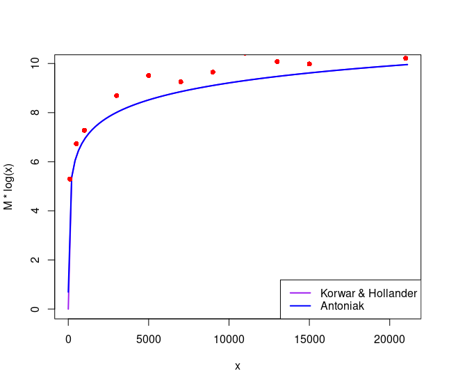

## M = 50

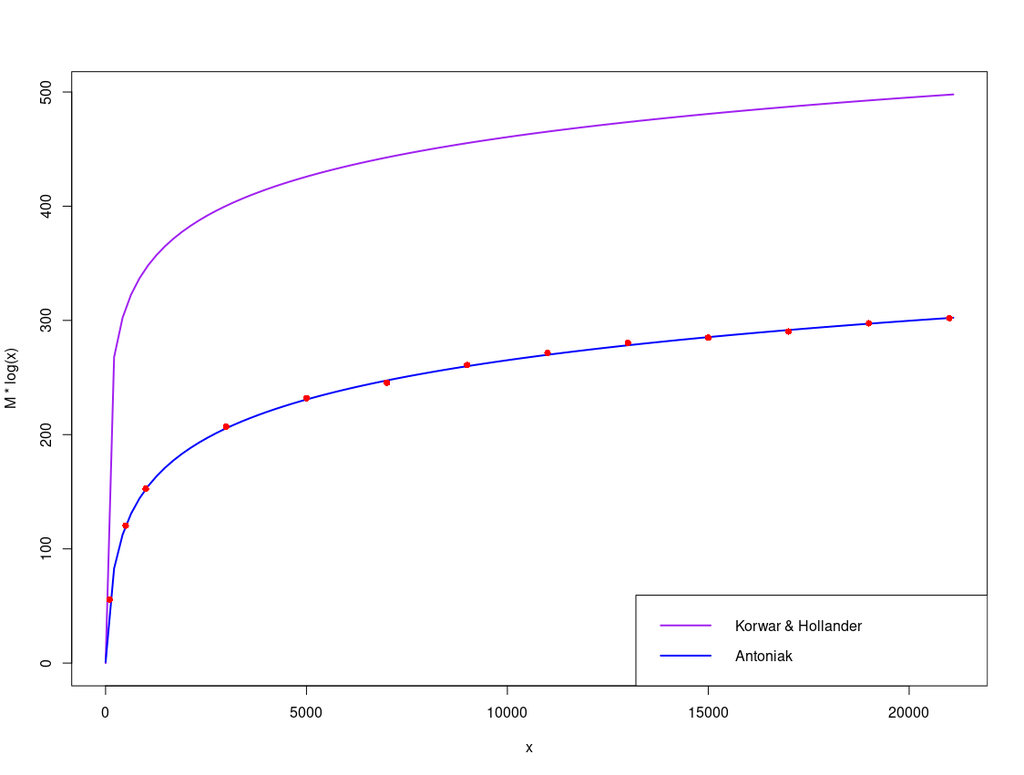

## M = 100

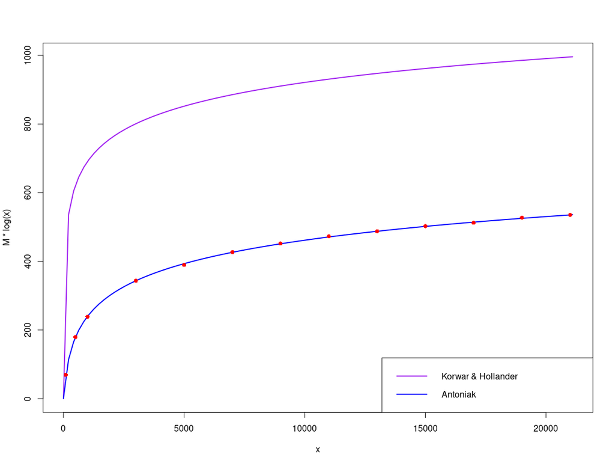

## M = 1000

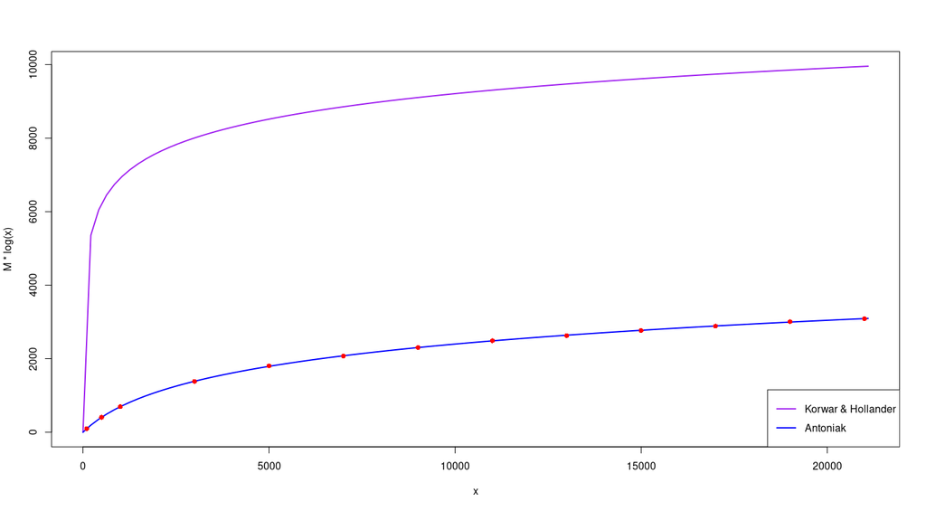

# 2. Posterior simulation

The main goal here is to obtain the posterior predictive distribution $P(Y_{n+1}|D_n)$ which involves an integral that is extremely computational involved. For this reason, we can use the results for the full conditionals of the posterior distribution to implement a Gibbs Sampler.

The first result stated in the paper is the following: For each $i$, the conditional posterior for $(\pi_i|\pi^{(i)}, D_n)$ is the mixture

$$\pi_i|\pi^{(i)}, D_n \sim q_0G_i(\pi_i) + \sum_{j\neq i}
q_j \delta_{\pi_j}(\pi_i)$$

or, equivalently,

$$\pi_i|\pi^{(i)}, D_n ~ \sim q_0G_i(\pi_i) + \sum_{j=1}^{k_i}
q_j^{*}\delta_{\pi_j^*}(\pi_i), \quad q^*_j = n_j q_j$$

where,

- $G_i(\pi_i) \equiv N-\Gamma^{-1}(x_i, 1/X; (1 + s)/2, S_i/2)$, that is,
  $$\begin{align*}
  \mu_i|V_i &\sim N(x_i, XV_i) \\
  V_i &\sim \Gamma^{-1}((1+s)/2,\, S_i/2)
  \end{align*}$$
- The weights $q_0$ are defined as

$$\begin{align*}
q_0 &\propto \alpha c(s)[1 + (y_i - m)^2/(sM)]^{-(1 +
s)/2}/M^{1/2} & \propto \alpha \cdot t_s(m, \sqrt{M})\\
q_j &\propto \exp[-(y_i - \mu_j)^2/(2V_j)](2V_j)^{-1/2}
&\propto N(\mu_j, V_j) \\
\sum_{j=0, j\neq i}^n q_j &= 1
\end{align*}$$

**Note**: the parameters are

- $x_i = (m + \tau y_i)/(1 + \tau)$
- $X = \tau/(1 + \tau)$
- $S_i = S + (y_i - m)^2/(1 + \tau)$
- $M = (1 + \tau)S/s$
- $c(s) = \Gamma((1 + s)/2)\Gamma(s/2)^{-1}s^{-1/2}$

## Algorithm 1

We can use these results to implement a Gibbs sampler with the following algorithm:

1. Choose starting values for $\pi$, which can be samples from the individual conditional posteriors $G_i$.
2. Sample elements of $\pi$ sequentially.

The algorithm is implemented in `01_EW_1995/algorithms.R`

### Recovering parameters

To illustrate this algorithm, first we’ll use a sample from a DPM model and see if we can recover the true parameters, which include the values of $\pi$ and $k$.

We simulate a sample of size 50 from a Dirichlet Process Mixture Model with parameters $M = 1$, $m = 0$, $\tau = 100$, $s = 50$ and $S = 2$. The reason for this is:

- For S I just fix the scale parameter of the inverse gamma distribution to 1. Now, a high value of s (relatively to S) gives us both low and less variable values for the variances. This is done so the data drawn from each cluster is close to each other
- Now, to better illustrate the different clusters, we have to make the means $\mu$ distant from each other. This is done by setting a large value of $\tau$.

We present the sampled values in the following figure.

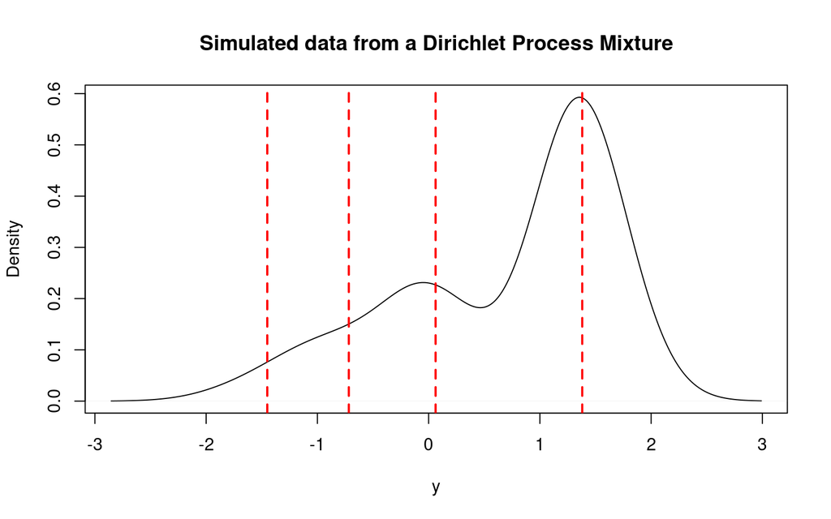

Next, we run the algorithm using the same priors used to simulate the data.

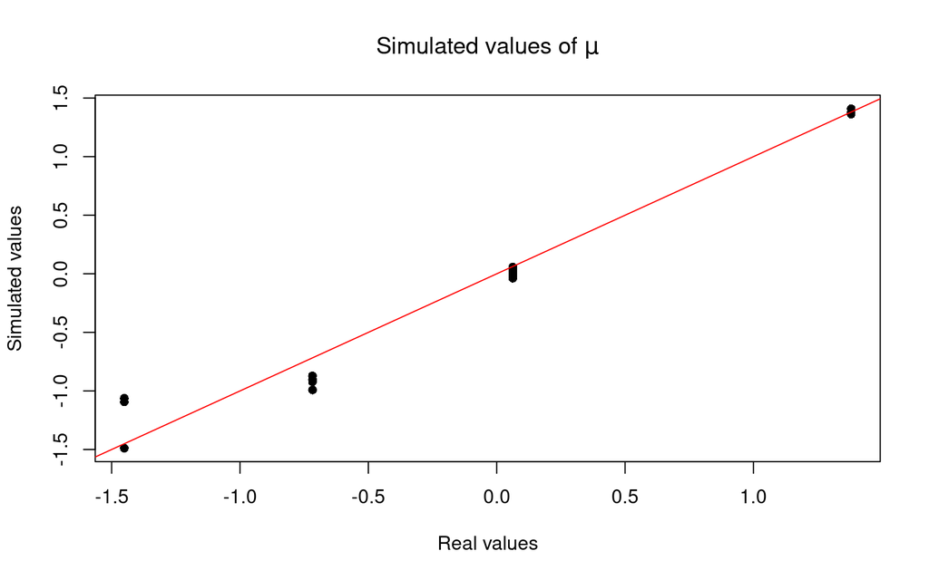

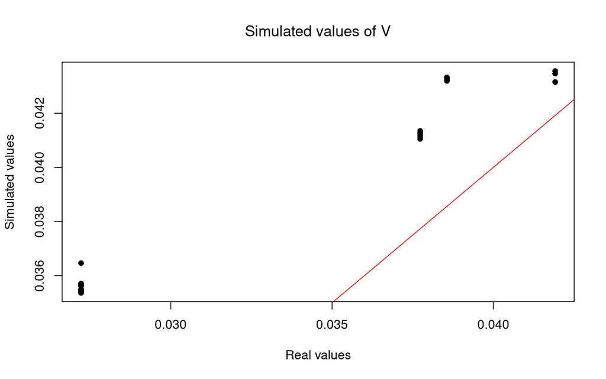

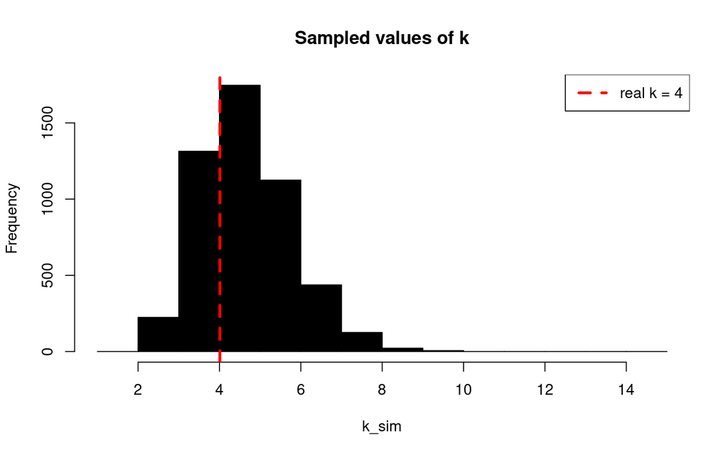

From the figures we can see that it retrieves correctly the mean for the component to the right, and that it tends to clump together the components that are near. On the other hand, the algorithm seems to overestimate the values of $V$.

### Recovering density

Now, we simulate data not directly from a DPM, and then try to recover the density. For this, we simulate data from the following model:

$$y_1, ..., y_n \overset{i.i.d}{\sim} p_1 N(-5, 1) + p_2 N(-1, 1) + p_3
N(0, 1) + p_4N(5, 1)$$

such that $p_1 + ... + p_4 = 1$. We simulate data from this mixture and then plot the true density in blue.

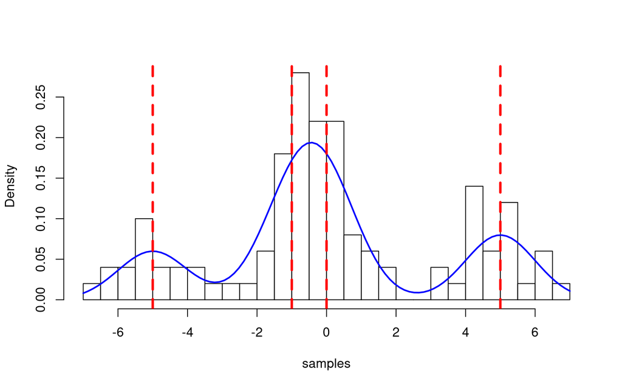

Now, we try to see if we can retrieve both the number of components and the real density.

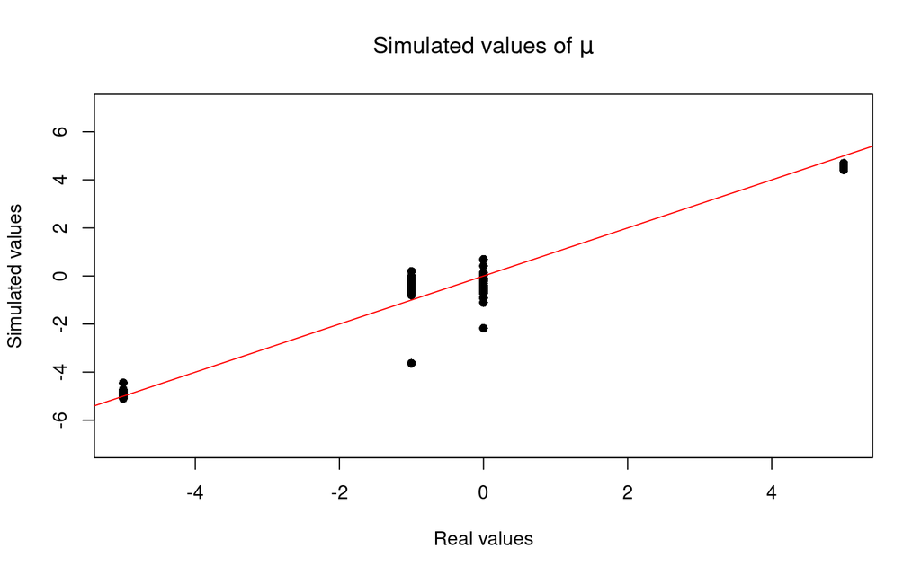

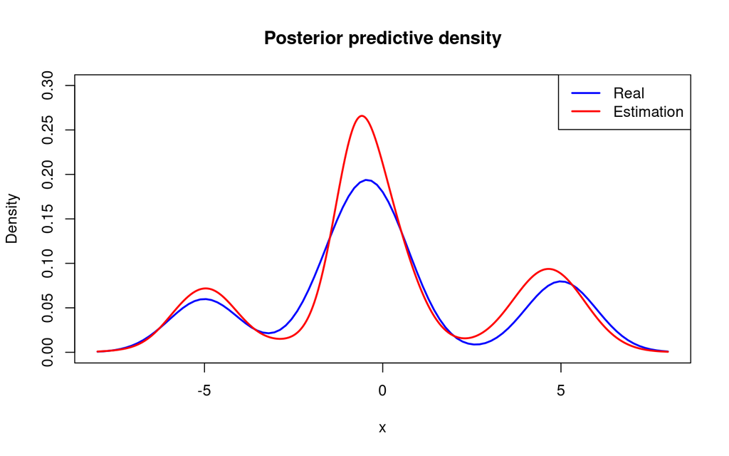

Finally, we repeat the example when trying to recover the real parameters, and check if the density estimate is close to the one that R gives (here we don’t know the real density)

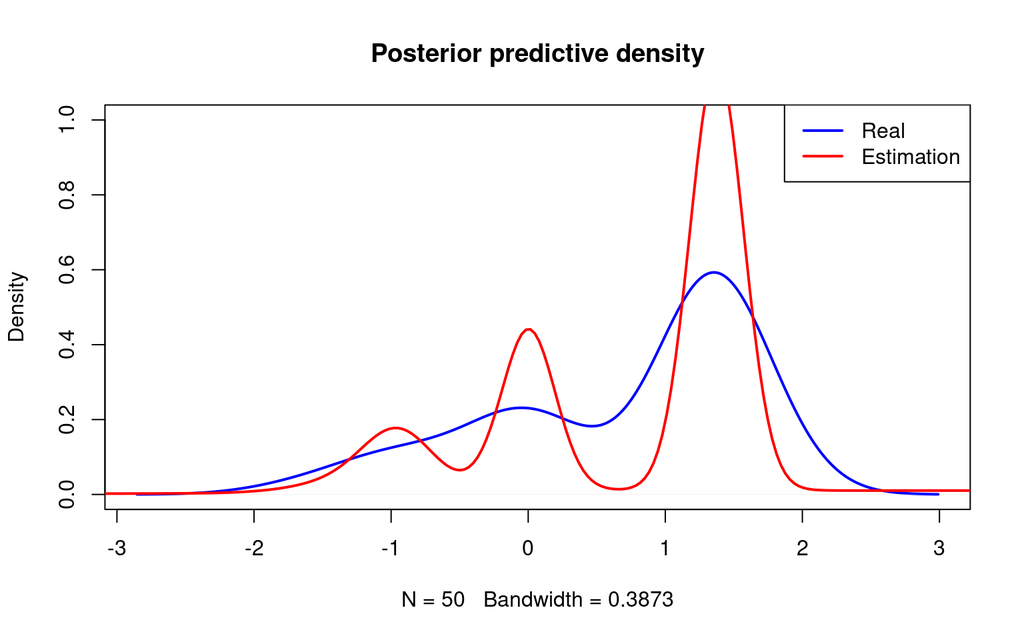

## Algorithm 2

Now we consider an extension of the model to include learning about the prior parameters $m$ and $\tau$. The model is:

$$\begin{align*}
Y_i | \pi_i &\overset{ind.}{\sim} \text{N}(\mu_i, V_i), \quad i =
1, ..., n \\
\pi_1, ..., \pi_n &\overset{i.i.d.}{\sim} G \\
G &\sim DP(\alpha, G_0) \\
G_0 &= N-\Gamma^{-1}(m, 1/\tau, s/2, S/2) \\
\tau &\sim \Gamma^{-1}(w/2, W/2) \\
m &\sim N(a, A)
\end{align*}$$

It follows that

- Given $\tau$ and $\pi$, $m$ is conditionally independent of $D_n$ with distribution

$$m | \tau, \pi \sim N\Big[(1 - x)a + x\bar{V}\sum(V_j^*)^{-1}\mu_j^*\,;\,
x\tau\bar{V}\Big]$$
where $x = A/(A + \tau \bar{V})$ and $\bar{V}^{-1} = \sum(V_j^*)^{-1}$.

- Given $m$ and $\pi$, $\tau$ is conditionally independent of $D_n$ with distribution

$$\tau | m, \pi \sim \Gamma^{-1}((w + k)/2, (W + K)/2)$$
where $K = \sum_{j=1}^k (\mu_j^* - m)^2/V_j^*$. The algorithm is implemented in `01_EW_1995/algorithms.R`.

Now we repeat the same experiments that we did with the first algorithm.

### Recovering Parameters

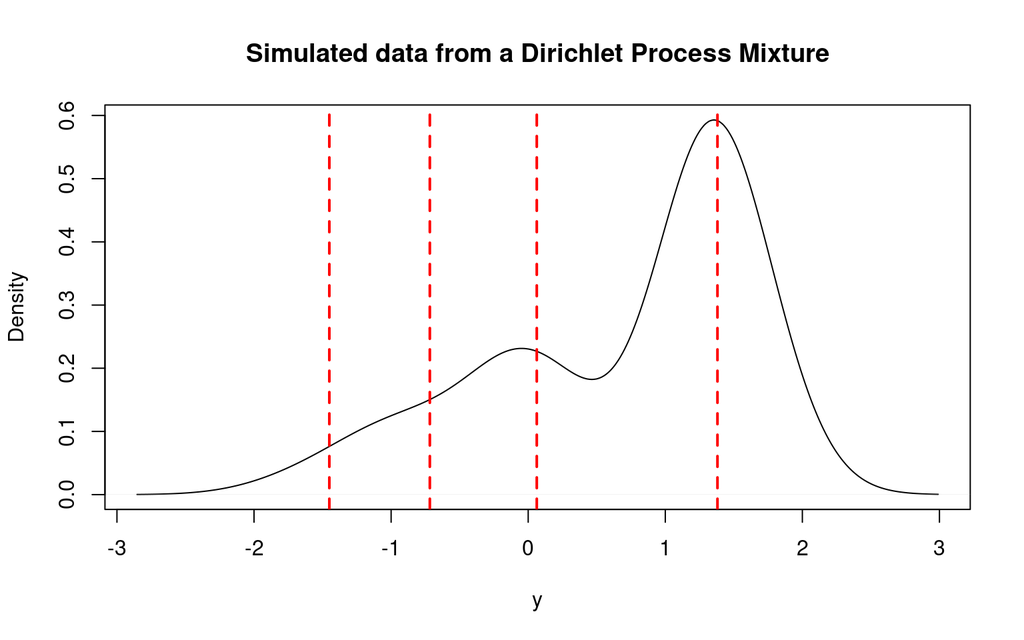

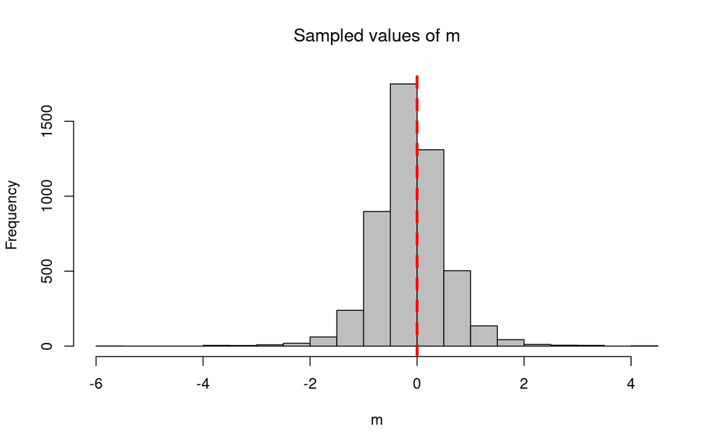

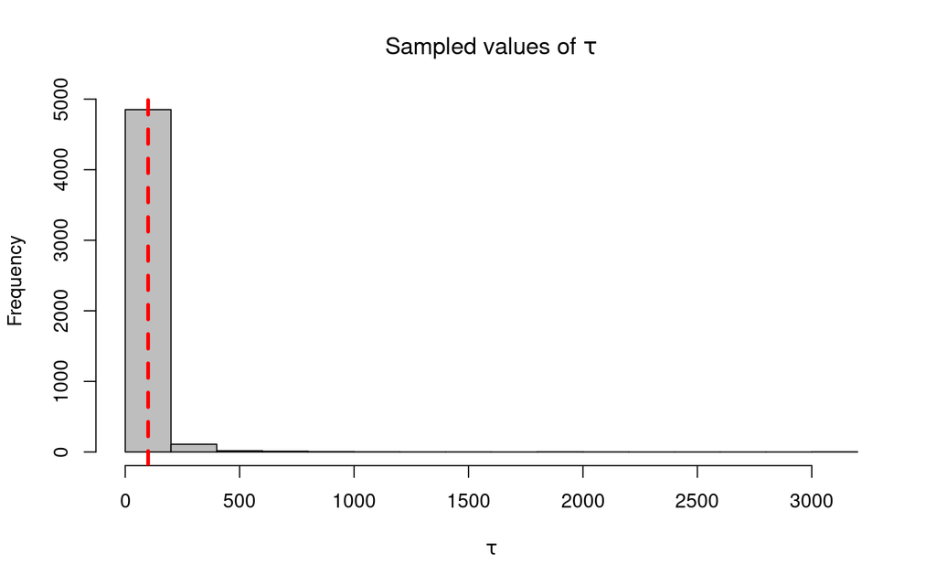

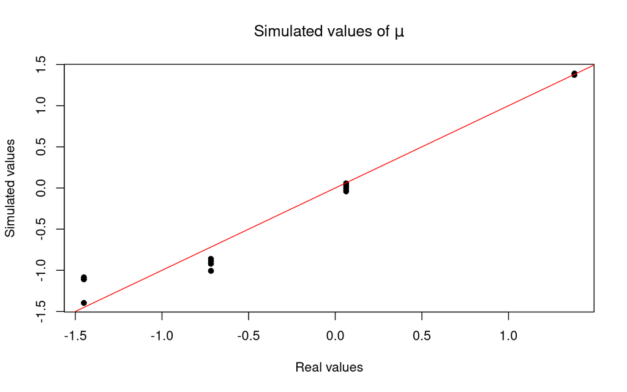

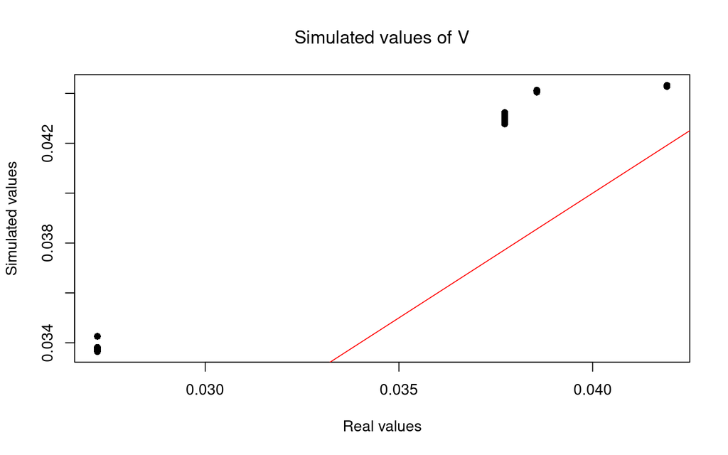

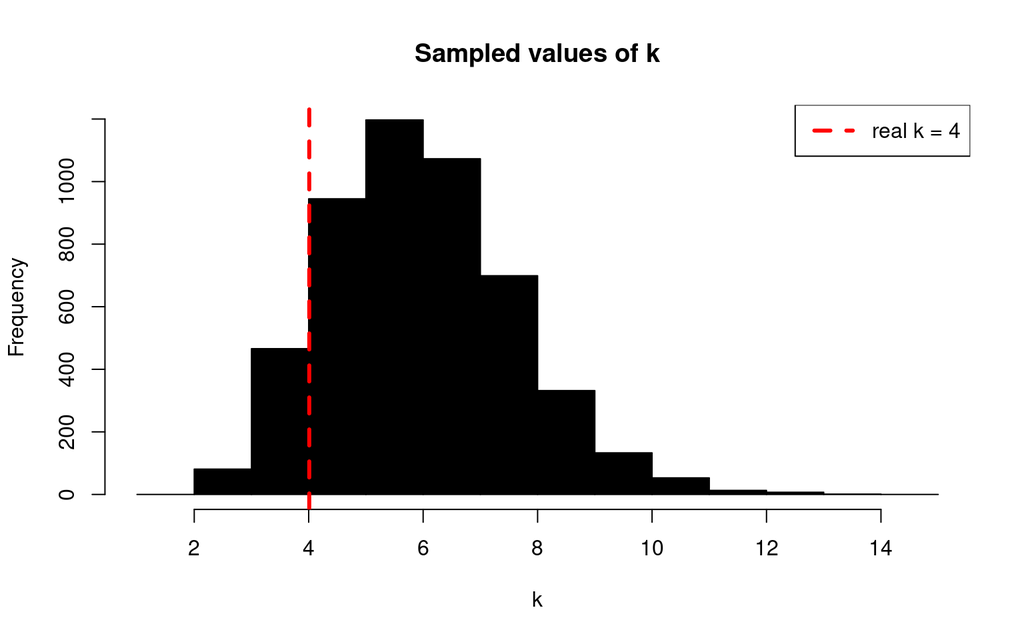

### Recovering Density

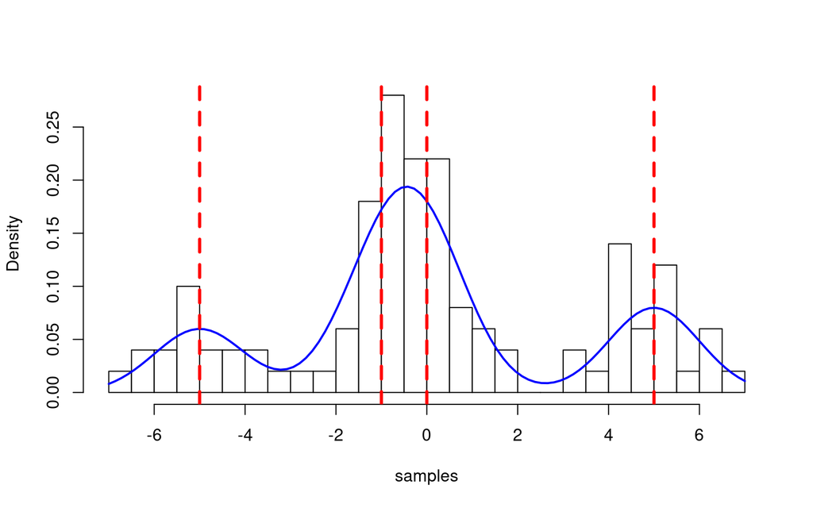

Now, we try to see if we can retrieve both the number of components and the real density.

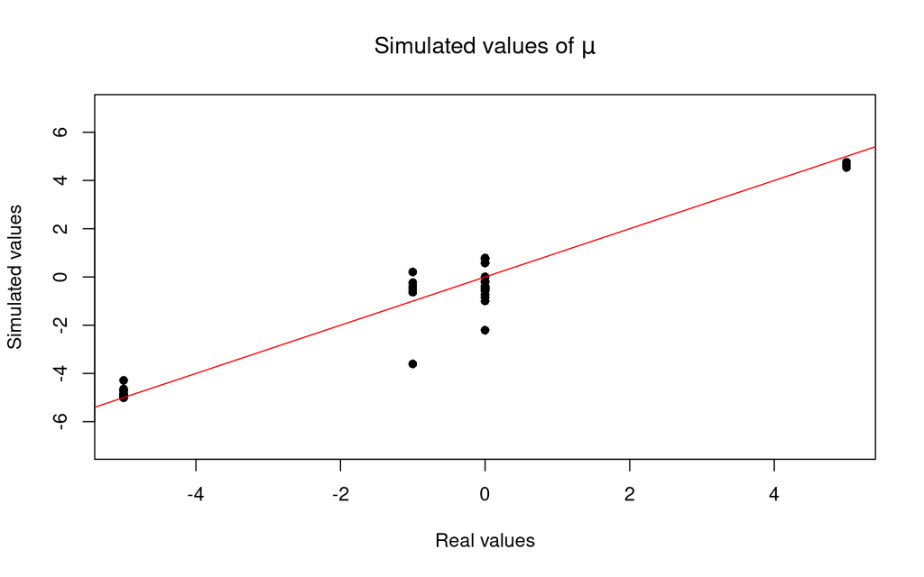

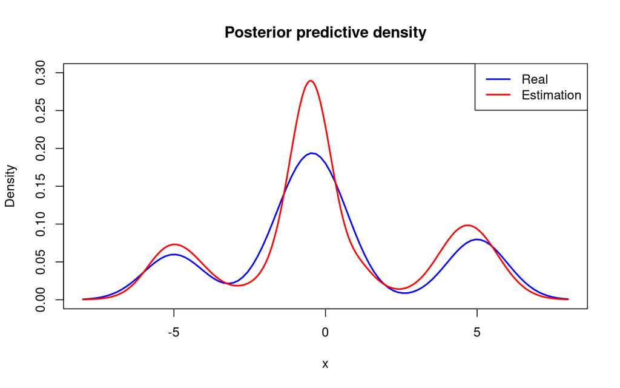

The results are almost the same.